# UdeSA - Clase 3

En la clase anterior habíamos visto como filtrar, transformar y resumir datos (entre otras operaciones). En uno de los últimos ejercicios creado la variable `Nivel` en el dataset `escuelas_nueva_categoria`, utilizando la función `case_when` y que clasificábamos cuántas escuelas teníamos según los niveles. Acá está el código por las dudas.

```r
escuelas <- escuelas %>%
  mutate(Nivel = case_when(comun_inic == "X" & comun_prim == "X" & comun_secu == "X" ~ "Inicial, Primaria y Secundaria",
                           comun_inic == "X" & comun_prim == "X" & comun_secu == ""~ "Incial y Primaria",
                           comun_inic == ""  & comun_prim == "X" & comun_secu == "X" ~ "Primaria y Secundaria",
                           comun_inic == ""  & comun_prim == "X" & comun_secu == "" ~ "Solo Primaria"))
```

Uno de los subsets que habíamos construido era `escuelas_comunes_por_provincia`. Ahora lo renombramos `escuelas_por_provincia`.

```r
escuelas_por_provincia <- escuelas %>%
  select(provincia, Nivel) %>%
  group_by(provincia, Nivel) %>%
  summarise(total = n())


head(escuelas_por_provincia)
```

```
## # A tibble: 6 x 3
## # Groups:   provincia [2]
##   provincia    Nivel                          total
##   <chr>        <chr>                          <int>
## 1 Buenos Aires Incial y Primaria                  2
## 2 Buenos Aires Primaria y Secundaria             10
## 3 Buenos Aires Solo Primaria                   4271
## 4 Catamarca    Incial y Primaria                  6
## 5 Catamarca    Inicial, Primaria y Secundaria     3
## 6 Catamarca    Primaria y Secundaria            142
```

Cómo se verán gråficamente estos datos? Para eso, podemos utilizar un gráficos de barras. La función a utilizar será `geom_bar()`. Todas las funciones para agregar geometrías en ggplot arrancan con `geom_`. Luego, con el parámetro `data` le decimos que datasets vamos a graficar. Luego de la coma, le tenemos que decir que `aesthetics` va a tener el gráfico. En este caso le decimos que en el *eje x* grafique los nombres de las provincias y en el *eje y* la cantidad total de observaciones.

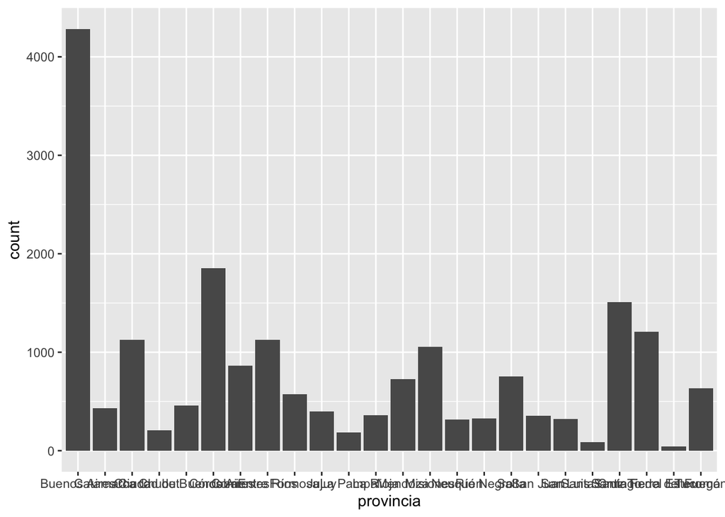

```r
ggplot() +
  geom_bar(data = escuelas_por_provincia,
           aes(x = provincia, weight = total))
```

Perfecto… perfecto? Estamos de acuerdo que mucho no se entiende? Entonces giremos los ejes. Para eso utilizamos la función `coord_flip()`:

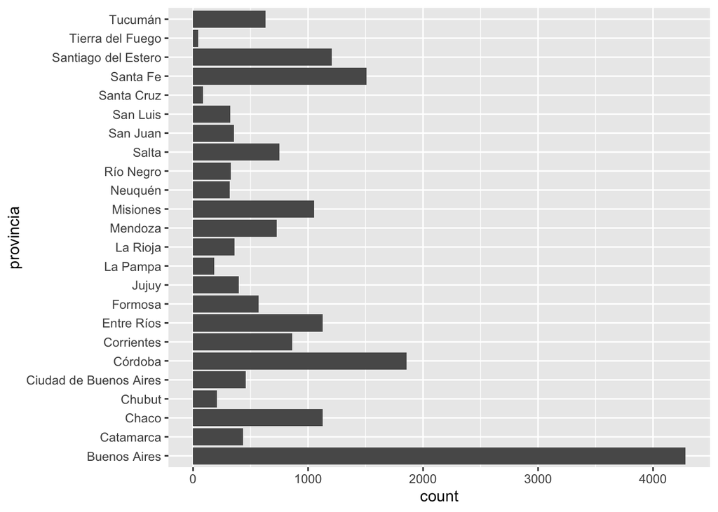

```r
ggplot() +
  geom_bar(data = escuelas_por_provincia, aes(x = provincia, weight = total)) +
  coord_flip()
```

Ahora queremos ver qué niveles de escuelas hay en cada una de las provincias, entonces hacemos un fill.

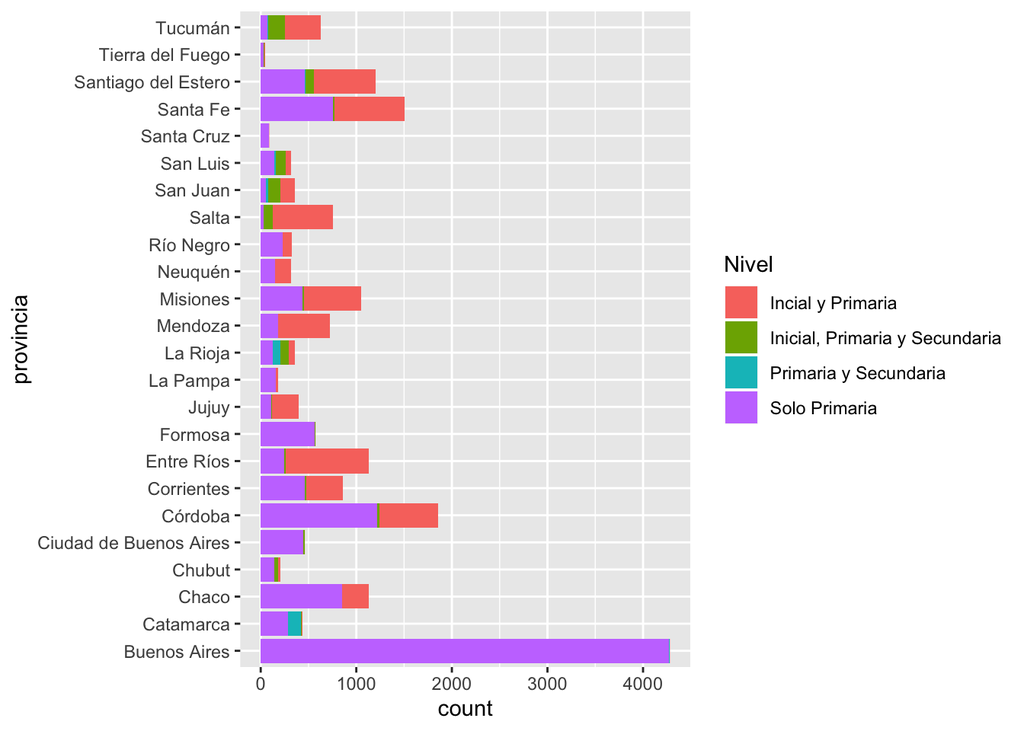

```r
ggplot() +
  geom_bar(data = escuelas_por_provincia,
           aes(x = provincia,
               weight = total,
               fill = Nivel)) +
  coord_flip()
```

```r
escuelas_nueva_categoria <- escuelas %>%
  group_by(provincia, Nivel) %>%
  tally()
```

Podemos ver un faceteado…

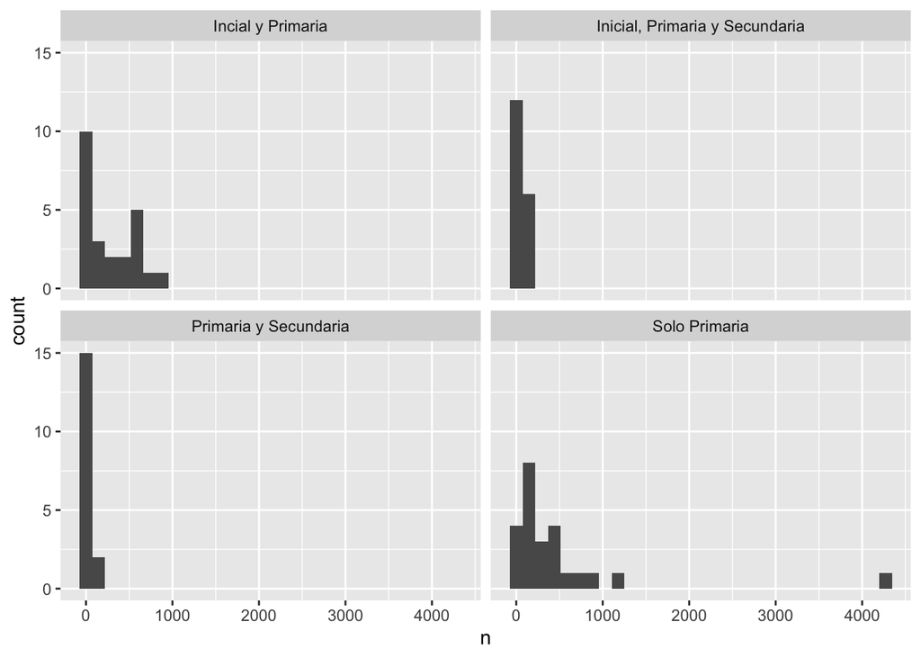

```r
ggplot(escuelas_nueva_categoria) +
    geom_histogram(aes(x = n)) +
    facet_wrap(~Nivel)
```

## 3. Provincia de Buenos Aires

Ahora hagamos foto en la Provincia de Buenos Aires. Para hacer un subset que contenga únicamente las escuelas de la Provincia de Buenos Aires. Una pregunta que nos gustaría responder es que relación hay entre la cantidad de escuelas y la cantidad de habitantes de cada uno de los partidos. Para eso, vamos a tener que trabajar un poquito con los datos.

La columna `cod_loc` hace referencia al código de localidad de INDEC. Los primeros dos dígitos hacen referencia a la provicia. Los segundos tres dígitos hacen referencia al departamento, partido o comuna. Los tres finales a la localidad. A nosotros nos interesa puntualmente los primeros 5 dígitos.

El código de provincia de la Provincia de Buenos Aires es “06”. Dado que nuestros datos no están del todo limpios, R toma la columna `cod_loc` como numérica y elimina el primer cero. Nosotros crearemos una nueva variable llamada `codigo_indec` que extraiga los primeros 4 dígitos y le anteponga un cero.

```r
escuelas_pba <- escuelas %>%
  filter(provincia == "Buenos Aires") %>%
  mutate(codigo_indec = paste0("0", str_extract(cod_loc, "[0-9]{4}")))
```

Ahora hagamos un subset para chequear como quedaron nuestros datos

```r
escuelas_pba_2 <- escuelas_pba %>%
  group_by(codigo_indec) %>%
  summarise(total = n())

head(escuelas_pba_2)
```

```
## # A tibble: 6 x 2
##   codigo_indec total
##   <chr>        <int>
## 1 06007           25
## 2 06014           17
## 3 06021           12
## 4 06028           82
## 5 06035           56
## 6 06042           36
```

De la clase anterior les debía cómo abrir archivos de Excel. Asique lo vamos a solucionar ahora. Para cargar los datos desde Excel vamos a utilizar la función `read_excel()`.

Para descargar el archivo a vuestras computadoras: https://bit.ly/2orzZA3

```r
pba <- read_excel("../datasets/Departamentos PBA.xlsx")
```

Ahora vamos a unir dos archivos. Para eso utilizaremos una función que se llama `left_join()`. A un dataset, le sumamos las variables de un segundo datassets. Le tenemos que definir que variable tienen en común ambos datasets.

```r
escuelas_pba_2 <- escuelas_pba_2 %>%
  left_join(pba, by = c("codigo_indec" = "Codigo INDEC"))

head(escuelas_pba_2)
```

```
## # A tibble: 6 x 4
##   codigo_indec total Partido                Poblacion
##   <chr>        <int> <chr>                      <dbl>
## 1 06007           25 Adolfo Alsina              17222
## 2 06014           17 Adolfo Gonzales Chaves     12168
## 3 06021           12 Alberti                    10746
## 4 06028           82 Almirante Brown           557025
## 5 06035           56 Avellaneda                345752
## 6 06042           36 Ayacucho                   20505
```

Ahora vemos la relación entre la cantidad de escuelas y la población!!

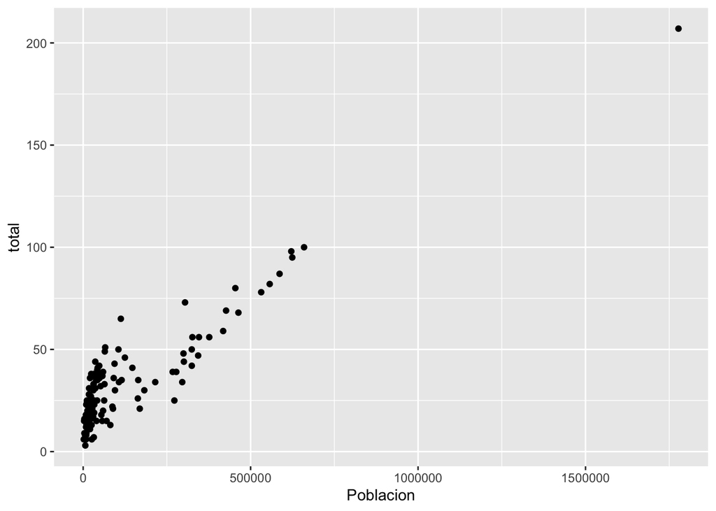

```r
ggplot() +
  geom_point(data = escuelas_pba_2,
             aes(x = Poblacion,
                 y = total))
```

Perfecto! Que pasa si en vez de puntos negros queremos ver puntos rojos?

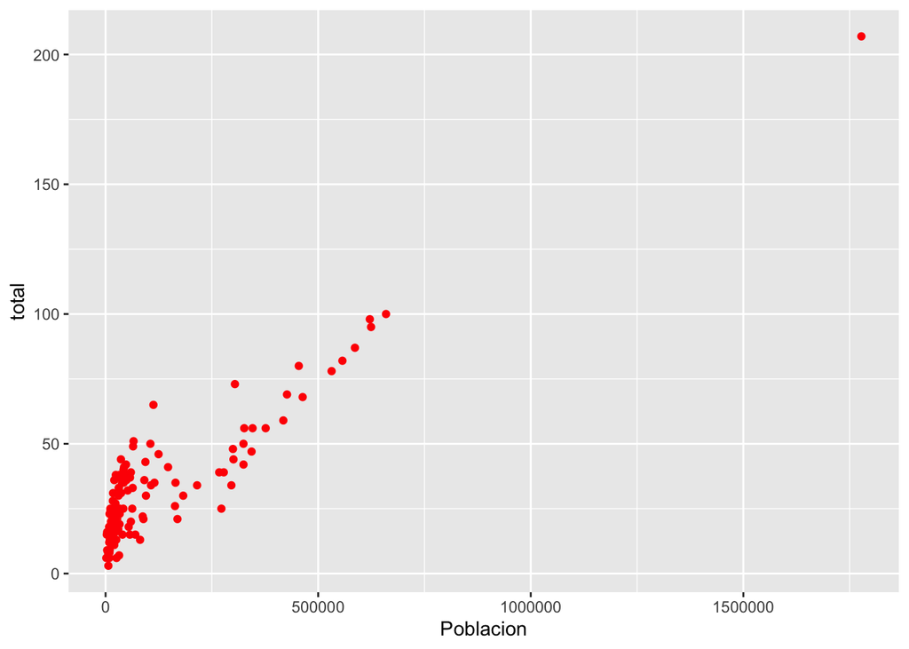

```r
ggplot() +
  geom_point(data = escuelas_pba_2,
             aes(x = Poblacion,
                 y = total),
                 color = "red")
```

Y si en vez de puntos queremos ver los nombres de las observaciones?

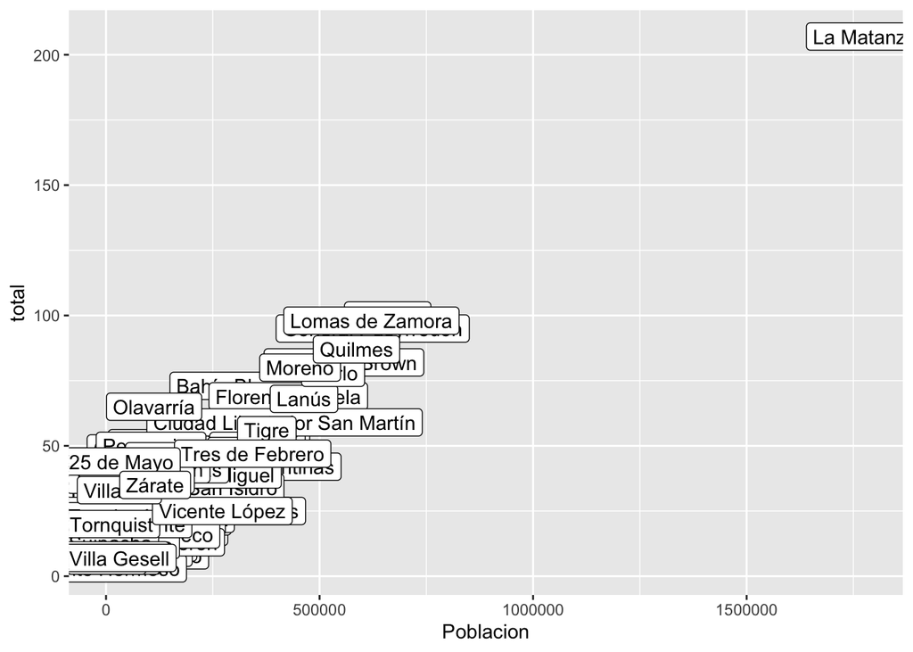

```r
ggplot() +
  geom_label(data = escuelas_pba_2,
             aes(x = Poblacion,
                 y = total, label = Partido))
```

## 4. Peinate que viene gente…

Les agregamos una leyenda:

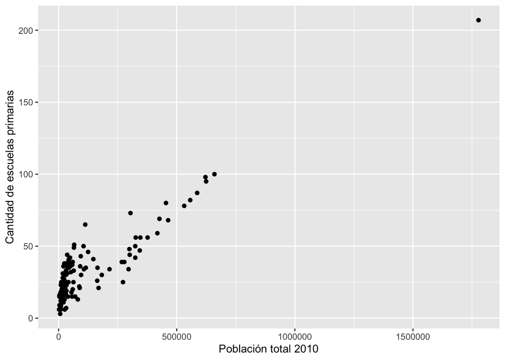

```r
ggplot() +
  geom_point(data = escuelas_pba_2, aes(x = Poblacion, y = total)) +
  labs(x = "Población total 2010",
       y = "Cantidad de escuelas primarias")
```

Les cambiamos como se ven

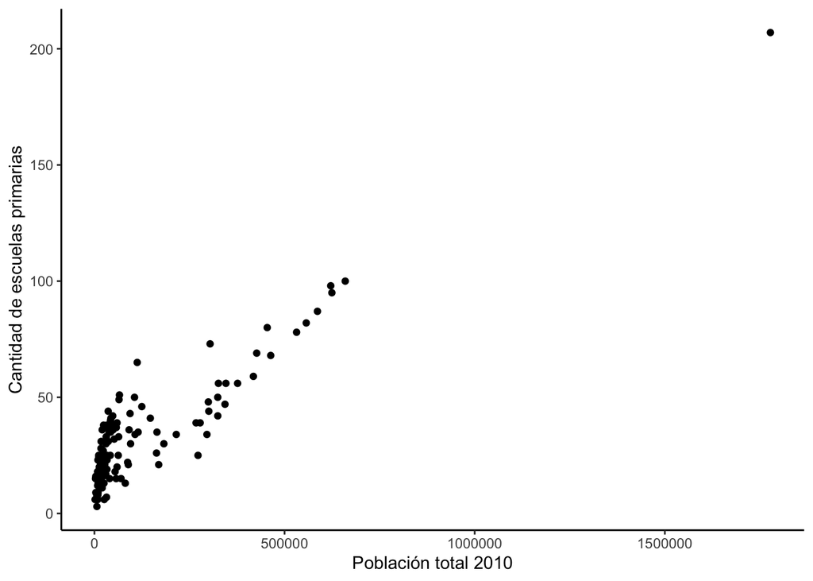

```r
ggplot() +
  geom_point(data = escuelas_pba_2, aes(x = Poblacion, y = total)) +
  labs(x = "Población total 2010",
       y = "Cantidad de escuelas primarias") +
  theme_classic()
```